# SA_01_PCSTAT_SUPPORT_ORG_NUM

Number of supported organizations · Number report

## Overview

**Description**

Number of supported organizations

**Table**

`SA-P01-T00-PUBLIC-CHARITY-STATUS` (one)

**Location code**

`SCHED-A-PART-01-LINE-12F`

**Family**

`SCHED-A-PART-01-LINE-12F`

**Data type**

numeric (xsd: IntegerNNType)

**Scope**

PZ

**Status**

unreviewed

3

xpaths mapped (3 observed)

496,161

filings with a value

2009–2024

tax years observed

1

open flags (1 errors)

## Flags

| Severity | Flag | Xpath | Detail |
| --- | --- | --- | --- |
| ⚠ error | `COLLISION` | IRS990ScheduleA/SupportedOrganizationsCnt | 214728 filings contain 2+ of its xpaths; most common set: /Return/ReturnData/IRS990ScheduleA/SupportedOrganizationsCnt ; /Return/ReturnData/IRS990ScheduleA/SupportedOrganizationsTotalCnt |

## Xpaths

All mapped xpaths (under /Return/ReturnData or /Return/ReturnHeader), oldest first. Charts label each series by its xpath.

| Xpath | Form | First year | Last year | Versions | Filings | Repeats in |
| --- | --- | --- | --- | --- | --- | --- |
| IRS990ScheduleA/TotalNumberOfSupportedOrgs | Sched A | 2009 | 2012 | 17 | 41,287 | 0.0% |
| IRS990ScheduleA/SupportedOrganizationsTotalCnt | Sched A | 2013 | 2024 | 37 | 231,243 | 0.0% |
| IRS990ScheduleA/SupportedOrganizationsCnt | Sched A | 2014 | 2024 | 34 | 223,631 | 0.0% |

## Coverage

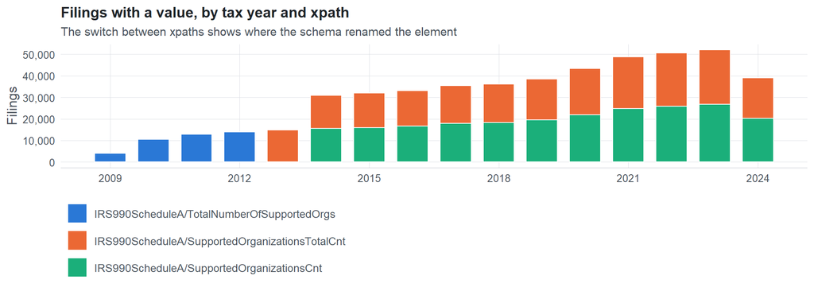

**Table view**

Table view: filings by tax year and series

| Tax year | IRS990ScheduleA/TotalNumberOfSupportedOrgs | IRS990ScheduleA/SupportedOrganizationsTotalCnt | IRS990ScheduleA/SupportedOrganizationsCnt |
| --- | --- | --- | --- |
| 2009 | 4,089 | 0 | 0 |
| 2010 | 10,480 | 0 | 0 |
| 2011 | 12,801 | 0 | 0 |
| 2012 | 13,917 | 0 | 0 |
| 2013 | 0 | 14,933 | 0 |
| 2014 | 0 | 15,476 | 15,521 |
| 2015 | 0 | 16,006 | 15,997 |
| 2016 | 0 | 16,562 | 16,591 |
| 2017 | 0 | 17,536 | 17,929 |
| 2018 | 0 | 17,853 | 18,266 |
| 2019 | 0 | 18,838 | 19,622 |
| 2020 | 0 | 21,396 | 21,963 |
| 2021 | 0 | 23,978 | 24,706 |
| 2022 | 0 | 24,698 | 25,912 |
| 2023 | 0 | 25,231 | 26,762 |
| 2024 | 0 | 18,736 | 20,362 |

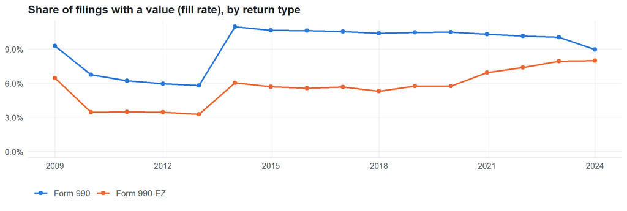

**Table view**

Table view: fill rate

| Tax year | Return type | Filings | All filings | Fill rate |
| --- | --- | --- | --- | --- |
| 2009 | Form 990 | 3,091 | 33,311 | 9.28% |
| 2009 | Form 990-EZ | 998 | 15,470 | 6.45% |
| 2010 | Form 990 | 8,295 | 123,025 | 6.74% |
| 2010 | Form 990-EZ | 2,185 | 63,326 | 3.45% |
| 2011 | Form 990 | 9,940 | 159,504 | 6.23% |
| 2011 | Form 990-EZ | 2,861 | 82,048 | 3.49% |
| 2012 | Form 990 | 10,680 | 179,688 | 5.94% |
| 2012 | Form 990-EZ | 3,237 | 93,750 | 3.45% |
| 2013 | Form 990 | 11,530 | 198,855 | 5.80% |
| 2013 | Form 990-EZ | 3,403 | 104,375 | 3.26% |
| 2014 | Form 990 | 23,977 | 218,619 | 10.97% |
| 2014 | Form 990-EZ | 7,020 | 116,417 | 6.03% |
| 2015 | Form 990 | 24,887 | 233,519 | 10.66% |
| 2015 | Form 990-EZ | 7,116 | 124,894 | 5.70% |
| 2016 | Form 990 | 25,886 | 243,903 | 10.61% |
| 2016 | Form 990-EZ | 7,267 | 130,484 | 5.57% |
| 2017 | Form 990 | 27,596 | 261,612 | 10.55% |
| 2017 | Form 990-EZ | 7,869 | 139,144 | 5.66% |
| 2018 | Form 990 | 28,189 | 271,442 | 10.38% |
| 2018 | Form 990-EZ | 7,930 | 149,384 | 5.31% |
| 2019 | Form 990 | 29,699 | 283,694 | 10.47% |
| 2019 | Form 990-EZ | 8,761 | 152,622 | 5.74% |
| 2020 | Form 990 | 33,610 | 320,342 | 10.49% |
| 2020 | Form 990-EZ | 9,749 | 169,864 | 5.74% |
| 2021 | Form 990 | 34,630 | 336,480 | 10.29% |
| 2021 | Form 990-EZ | 14,052 | 202,724 | 6.93% |
| 2022 | Form 990 | 35,374 | 349,055 | 10.13% |
| 2022 | Form 990-EZ | 15,234 | 206,130 | 7.39% |
| 2023 | Form 990 | 35,626 | 354,768 | 10.04% |
| 2023 | Form 990-EZ | 16,365 | 206,379 | 7.93% |
| 2024 | Form 990 | 24,818 | 277,298 | 8.95% |
| 2024 | Form 990-EZ | 14,280 | 178,867 | 7.98% |

## Values

| Result | Check | Detail |
| --- | --- | --- |
| ✓ pass | Values parse as numbers | 100.0% of values are numeric |
| ✓ pass | No sudden change in the median between adjacent years | largest change 2.2x (IRS990ScheduleA/SupportedOrganizationsCnt, 990EZ, TY2023) |
| ✓ pass | Pooled xpaths are on the same scale (same return type) | largest ratio of medians between xpaths: 1.0x |
| ✓ pass | One scale across xpaths (fraction vs percent) | IRS990ScheduleA/SupportedOrganizationsCnt: percent or small count; IRS990ScheduleA/SupportedOrganizationsTotalCnt: percent or small count; IRS990ScheduleA/TotalNumberOfSupportedOrgs: percent or small … |

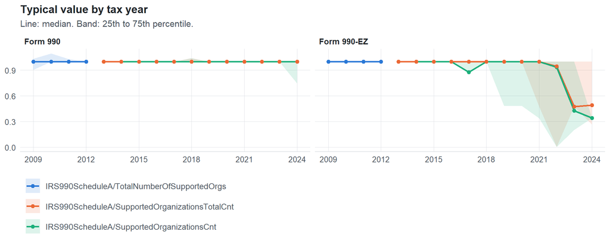

**Table view**

Table view: quartiles by tax year

| Series | Return | Tax year | Filings | P25 | Median | P75 |
| --- | --- | --- | --- | --- | --- | --- |
| IRS990ScheduleA/TotalNumberOfSupportedOrgs | 990 | 2009 | 3,091 | 0.90 | 1 | 1.03 |
| IRS990ScheduleA/TotalNumberOfSupportedOrgs | 990 | 2010 | 8,295 | 1 | 1 | 1.10 |
| IRS990ScheduleA/TotalNumberOfSupportedOrgs | 990 | 2011 | 9,940 | 1 | 1 | 1.03 |
| IRS990ScheduleA/TotalNumberOfSupportedOrgs | 990 | 2012 | 10,680 | 1 | 1 | 1 |
| IRS990ScheduleA/TotalNumberOfSupportedOrgs | 990EZ | 2009 | 998 | 1 | 1 | 1 |
| IRS990ScheduleA/TotalNumberOfSupportedOrgs | 990EZ | 2010 | 2,185 | 1 | 1 | 1 |
| IRS990ScheduleA/TotalNumberOfSupportedOrgs | 990EZ | 2011 | 2,861 | 1 | 1 | 1 |
| IRS990ScheduleA/TotalNumberOfSupportedOrgs | 990EZ | 2012 | 3,237 | 1 | 1 | 1 |
| IRS990ScheduleA/SupportedOrganizationsTotalCnt | 990 | 2013 | 11,530 | 1 | 1 | 1 |
| IRS990ScheduleA/SupportedOrganizationsTotalCnt | 990 | 2014 | 11,985 | 1 | 1 | 1 |
| IRS990ScheduleA/SupportedOrganizationsTotalCnt | 990 | 2015 | 12,443 | 1 | 1 | 1 |
| IRS990ScheduleA/SupportedOrganizationsTotalCnt | 990 | 2016 | 12,937 | 1 | 1 | 1 |
| IRS990ScheduleA/SupportedOrganizationsTotalCnt | 990 | 2017 | 13,787 | 1 | 1 | 1 |
| IRS990ScheduleA/SupportedOrganizationsTotalCnt | 990 | 2018 | 14,083 | 1 | 1 | 1.04 |
| IRS990ScheduleA/SupportedOrganizationsTotalCnt | 990 | 2019 | 14,836 | 1 | 1 | 1 |
| IRS990ScheduleA/SupportedOrganizationsTotalCnt | 990 | 2020 | 16,779 | 1 | 1 | 1 |
| IRS990ScheduleA/SupportedOrganizationsTotalCnt | 990 | 2021 | 17,257 | 1 | 1 | 1 |
| IRS990ScheduleA/SupportedOrganizationsTotalCnt | 990 | 2022 | 17,543 | 1 | 1 | 1 |
| IRS990ScheduleA/SupportedOrganizationsTotalCnt | 990 | 2023 | 17,613 | 1 | 1 | 1 |
| IRS990ScheduleA/SupportedOrganizationsTotalCnt | 990 | 2024 | 12,179 | 1 | 1 | 1 |
| IRS990ScheduleA/SupportedOrganizationsTotalCnt | 990EZ | 2013 | 3,403 | 1 | 1 | 1 |
| IRS990ScheduleA/SupportedOrganizationsTotalCnt | 990EZ | 2014 | 3,491 | 1 | 1 | 1 |
| IRS990ScheduleA/SupportedOrganizationsTotalCnt | 990EZ | 2015 | 3,563 | 1 | 1 | 1 |
| IRS990ScheduleA/SupportedOrganizationsTotalCnt | 990EZ | 2016 | 3,625 | 1 | 1 | 1 |
| IRS990ScheduleA/SupportedOrganizationsTotalCnt | 990EZ | 2017 | 3,749 | 1 | 1 | 1 |
| IRS990ScheduleA/SupportedOrganizationsTotalCnt | 990EZ | 2018 | 3,770 | 1 | 1 | 1 |
| IRS990ScheduleA/SupportedOrganizationsTotalCnt | 990EZ | 2019 | 4,002 | 1 | 1 | 1 |
| IRS990ScheduleA/SupportedOrganizationsTotalCnt | 990EZ | 2020 | 4,617 | 1 | 1 | 1 |
| IRS990ScheduleA/SupportedOrganizationsTotalCnt | 990EZ | 2021 | 6,720 | 0.47 | 1 | 1 |
| IRS990ScheduleA/SupportedOrganizationsTotalCnt | 990EZ | 2022 | 7,154 | 0.01 | 0.95 | 1 |
| IRS990ScheduleA/SupportedOrganizationsTotalCnt | 990EZ | 2023 | 7,617 | 0.47 | 0.47 | 1 |
| IRS990ScheduleA/SupportedOrganizationsTotalCnt | 990EZ | 2024 | 6,557 | 0.26 | 0.49 | 1 |
| IRS990ScheduleA/SupportedOrganizationsCnt | 990 | 2014 | 11,992 | 1 | 1 | 1 |
| IRS990ScheduleA/SupportedOrganizationsCnt | 990 | 2015 | 12,444 | 1 | 1 | 1 |
| IRS990ScheduleA/SupportedOrganizationsCnt | 990 | 2016 | 12,949 | 1 | 1 | 1 |
| IRS990ScheduleA/SupportedOrganizationsCnt | 990 | 2017 | 13,809 | 1 | 1 | 1 |
| IRS990ScheduleA/SupportedOrganizationsCnt | 990 | 2018 | 14,106 | 1 | 1 | 1.04 |
| IRS990ScheduleA/SupportedOrganizationsCnt | 990 | 2019 | 14,863 | 1 | 1 | 1 |
| IRS990ScheduleA/SupportedOrganizationsCnt | 990 | 2020 | 16,831 | 1 | 1 | 1 |
| IRS990ScheduleA/SupportedOrganizationsCnt | 990 | 2021 | 17,373 | 1 | 1 | 1 |
| IRS990ScheduleA/SupportedOrganizationsCnt | 990 | 2022 | 17,831 | 1 | 1 | 1 |
| IRS990ScheduleA/SupportedOrganizationsCnt | 990 | 2023 | 18,013 | 1 | 1 | 1 |
| IRS990ScheduleA/SupportedOrganizationsCnt | 990 | 2024 | 12,639 | 0.75 | 1 | 1 |
| IRS990ScheduleA/SupportedOrganizationsCnt | 990EZ | 2014 | 3,529 | 1 | 1 | 1 |
| IRS990ScheduleA/SupportedOrganizationsCnt | 990EZ | 2015 | 3,553 | 1 | 1 | 1 |
| IRS990ScheduleA/SupportedOrganizationsCnt | 990EZ | 2016 | 3,642 | 1 | 1 | 1 |
| IRS990ScheduleA/SupportedOrganizationsCnt | 990EZ | 2017 | 4,120 | 0.88 | 0.88 | 1 |
| IRS990ScheduleA/SupportedOrganizationsCnt | 990EZ | 2018 | 4,160 | 1 | 1 | 1 |
| IRS990ScheduleA/SupportedOrganizationsCnt | 990EZ | 2019 | 4,759 | 0.48 | 1 | 1 |
| IRS990ScheduleA/SupportedOrganizationsCnt | 990EZ | 2020 | 5,132 | 0.49 | 1 | 1 |
| IRS990ScheduleA/SupportedOrganizationsCnt | 990EZ | 2021 | 7,332 | 0.34 | 1 | 1 |
| IRS990ScheduleA/SupportedOrganizationsCnt | 990EZ | 2022 | 8,080 | 0.01 | 0.94 | 1 |
| IRS990ScheduleA/SupportedOrganizationsCnt | 990EZ | 2023 | 8,748 | 0.20 | 0.43 | 1 |
| IRS990ScheduleA/SupportedOrganizationsCnt | 990EZ | 2024 | 7,723 | 0.34 | 0.34 | 0.34 |

Summary by xpath and return type (all years)

| Series | Return | Filings | % numeric | % zero | % negative | Median (typical year) | P99 (typical year) |
| --- | --- | --- | --- | --- | --- | --- | --- |
| IRS990ScheduleA/TotalNumberOfSupportedOrgs | 990 | 32,006 | 100 | 0.48 | 0 | 1 | 16 |
| IRS990ScheduleA/TotalNumberOfSupportedOrgs | 990EZ | 9,281 | 100 | 0.10 | 0 | 1 | 6 |
| IRS990ScheduleA/SupportedOrganizationsTotalCnt |  | 3 |  |  |  |  |  |
| IRS990ScheduleA/SupportedOrganizationsTotalCnt | 990 | 172,972 | 100 | 1.01 | 0 | 1 | 18 |
| IRS990ScheduleA/SupportedOrganizationsTotalCnt | 990EZ | 58,268 | 100 | 14.86 | 0 | 1 | 7 |
| IRS990ScheduleA/SupportedOrganizationsCnt |  | 3 |  |  |  |  |  |
| IRS990ScheduleA/SupportedOrganizationsCnt | 990 | 162,850 | 100 | 2.00 | 0 | 1 | 19 |
| IRS990ScheduleA/SupportedOrganizationsCnt | 990EZ | 60,778 | 100 | 24.61 | 0 | 1 | 7 |

Scale of each xpath

| Series | P99 (typical year) | Implied scale |
| --- | --- | --- |
| IRS990ScheduleA/SupportedOrganizationsCnt | 11 | percent or small count |
| IRS990ScheduleA/SupportedOrganizationsTotalCnt | 11 | percent or small count |
| IRS990ScheduleA/TotalNumberOfSupportedOrgs | 8 | percent or small count |

## Examples

| Tax year | Return | Xpath | Organization | Value | Source |
| --- | --- | --- | --- | --- | --- |
| 2024 | 990 | IRS990ScheduleA/SupportedOrganizationsCnt | DNI 4 INC | 1 | [XML](https://gt990datalake-rawdata.s3.amazonaws.com/EfileData/XmlFiles/202630719349301148_public.xml) |
| 2024 | 990 | IRS990ScheduleA/SupportedOrganizationsTotalCnt | KRESS FARM GARDEN PRESERVE | 1 | [XML](https://gt990datalake-rawdata.s3.amazonaws.com/EfileData/XmlFiles/202523219349303827_public.xml) |
| 2023 | 990EZ | IRS990ScheduleA/SupportedOrganizationsCnt | MONTGOMERY HOSPITAL WORKERS COMPENSATION | 3 | [XML](https://gt990datalake-rawdata.s3.amazonaws.com/EfileData/XmlFiles/202521349349204322_public.xml) |
| 2023 | 990 | IRS990ScheduleA/SupportedOrganizationsTotalCnt | LC DANESE G BORLAND CHARITTRUST | 1 | [XML](https://gt990datalake-rawdata.s3.amazonaws.com/EfileData/XmlFiles/202401089349300915_public.xml) |
| 2022 | 990 | IRS990ScheduleA/SupportedOrganizationsCnt | HARI AND ANJALI AGRAWAL CHARITABLE FDN | 1 | [XML](https://gt990datalake-rawdata.s3.amazonaws.com/EfileData/XmlFiles/202343159349301744_public.xml) |
| 2022 | 990 | IRS990ScheduleA/SupportedOrganizationsTotalCnt | Alexian Brothers - AHS Midwest Region Health Co | 18 | [XML](https://gt990datalake-rawdata.s3.amazonaws.com/EfileData/XmlFiles/202401369349308605_public.xml) |
| 2021 | 990EZ | IRS990ScheduleA/SupportedOrganizationsCnt | BLAINE 1 INC | 1 | [XML](https://gt990datalake-rawdata.s3.amazonaws.com/EfileData/XmlFiles/202201369349200340_public.xml) |
| 2021 | 990EZ | IRS990ScheduleA/SupportedOrganizationsTotalCnt | BLAINE 1 INC | 1 | [XML](https://gt990datalake-rawdata.s3.amazonaws.com/EfileData/XmlFiles/202201369349200340_public.xml) |
| 2020 | 990 | IRS990ScheduleA/SupportedOrganizationsCnt | POTLIKKER CAPITAL | 1 | [XML](https://gt990datalake-rawdata.s3.amazonaws.com/EfileData/XmlFiles/202301019349300515_public.xml) |
| 2020 | 990 | IRS990ScheduleA/SupportedOrganizationsTotalCnt | THE ANNIE EATON SOCIETY INC | 1 | [XML](https://gt990datalake-rawdata.s3.amazonaws.com/EfileData/XmlFiles/202123089349304852_public.xml) |
| 2019 | 990 | IRS990ScheduleA/SupportedOrganizationsCnt | The Stronghold Fund | 1 | [XML](https://gt990datalake-rawdata.s3.amazonaws.com/EfileData/XmlFiles/202021339349301717_public.xml) |
| 2019 | 990 | IRS990ScheduleA/SupportedOrganizationsTotalCnt | BAPTIST BESTHEALTH INC | 1 | [XML](https://gt990datalake-rawdata.s3.amazonaws.com/EfileData/XmlFiles/202112259349301966_public.xml) |

## Reviewer checklist

- The definition matches the form line and instructions for every xpath’s schema years.
- Every xpath pooled here measures the same thing on the 990 and 990-EZ (close enough for analysis).
- The coverage chart has no unexplained gaps or jumps between tax years.
- Each open flag is fixed, or accepted with a note in validation_log.csv.
- Counts are whole numbers and plausible (e.g. employees, volunteers, voting members).
- Ratios and percentages use one scale (0-1 or 0-100) across all xpaths and years.
- Units match the form line (hours per week, number of states, percent of support).

Record the review as a row in `inst/extdata/src/validation_log.csv` (variable_name, reviewer, date, status, note). Evidence built 2026-09-23 17:09:04 MST from the ef2 DuckDB builds (tax years 2009–2024).